# Final Project

Vaishnavi Kadambi

11/29/2019

### Question 1:

#### (1)

I went to the url in the description and downloaded the Parks and Recreation script data from Kaggle in a zip form. I opened the zip and got access the to folder called scripts.

#### (2)

I downloaded the imbd.RData file from CCLE which contains the IMDb data on Parks and Rec Rating. Then I download the RData into my global environment, which in this case is a matrix with the episode rating and the number of ratings. I downloaded it to my local environment by simply double clicking on the RData file.

#### (3)

I collect the viewership data for parks and rec from wikipedia by using the supplied code in the spec. First, I had to install the rvest package by going into the Tools Bar and using the Install Packages option. Then I entered the following code.

```r
library(rvest)
url <- "https://en.wikipedia.org/wiki/List_of_Parks_and_Recreation_episodes"
episode_data <- html_table(html_nodes(read_html(url),xpath="//*/table"),fill=TRUE)
parks_and_rec <- Reduce("rbind",episode_data[2:8])
parks_and_rec$Title <- gsub(pattern="[^0-9a-zA-Z.,' ]", replacement="",parks_and_rec$Title)

head(parks_and_rec)
```

```
##   No.overall No. inseason        Title          Directed by
## 1          1            1        Pilot         Greg Daniels
## 2          2            2   Canvassing          Seth Gordon
## 3          3            3 The Reporter        Jeffrey Blitz
## 4          4            4   Boys' Club    Michael McCullers
## 5          5            5  The Banquet Beth McCarthy-Miller
## 6          6            6    Rock Show        Michael Schur
##                     Written by           Original air date
## 1 Greg Daniels & Michael Schur  April 9, 2009 (2009-04-09)
## 2                 Rachel Axler April 16, 2009 (2009-04-16)
## 3                     Dan Goor April 23, 2009 (2009-04-23)
## 4                    Alan Yang April 30, 2009 (2009-04-30)
## 5                Tucker Cawley    May 7, 2009 (2009-05-07)
## 6                 Norm Hiscock   May 14, 2009 (2009-05-14)
##   U.S. viewers(millions)
## 1                6.77[9]
## 2               5.92[10]
## 3               5.24[11]
## 4               5.29[12]
## 5               4.64[13]
## 6               4.25[14]
```

I added the head function to check if the contents of parks_and_rec matched the example given in the homework and it does!

Now, we have to import the data from all the three sources into R. I first made sure that all the sources and this final project Rmd file were all in the same directory(I put them all in a folder called Final).

```r
getwd()
```

```
## [1] "/Users/vyshukadambi/Desktop/Final"
```

```r
setwd("/Users/vyshukadambi/Desktop/Final/scripts")
csv_file <- dir()
scripts <- read.csv(csv_file[1],stringsAsFactors = FALSE)
scripts <- cbind(scripts,"Episode.Num"= 1)
for (i in 2:length(csv_file)){
  current_csv <- read.csv(csv_file[i],stringsAsFactors = FALSE)
  current_csv <- cbind(current_csv,"Episode.Num"= i)
  scripts <- rbind(scripts,current_csv)
}
head(scripts)
```

```
##      Character
## 1 Leslie Knope
## 2 Leslie Knope
## 3 Leslie Knope
## 4 Leslie Knope
## 5 Leslie Knope
## 6 Leslie Knope
##                                                                                                                                                                 Line
## 1                                                                                                                                                             Hello.
## 2                                                                                                                                                                Hi.
## 3                                                                                       My name is Leslie Knope, and I work for the Parks and Recreation Department.
## 4                                                                                                                                     Can I ask you a few questions?
## 5 Would you say that you are, "Enjoying yourself and having fun, having a moderate amount of fun and somewhat enjoying yourself, or having no fun and no enjoyment?"
## 6                                                                                                                                        I'm gonna put a lot of fun.
##   Episode.Num
## 1           1
## 2           1
## 3           1
## 4           1
## 5           1
## 6           1
```

This command simply loads the matrix imdb from the imdb.RData function using the load function.

```r
load("imdb.RData")
```

We don’t need to load or add the parks_and_rec data frame because it’s already in our global environment. Now I am going to verify that each object has been correctly created by printing the variable names, using the colnames function, and the dimensions of each object, using the dim function.

```r
colnames(scripts)
```

```
## [1] "Character"   "Line"        "Episode.Num"
```

```r
colnames(imdb)
```

```
## [1] "rating" "votes"
```

```r
colnames(parks_and_rec)
```

```
## [1] "No.overall"             "No. inseason"
## [3] "Title"                  "Directed by"
## [5] "Written by"             "Original air date"
## [7] "U.S. viewers(millions)"
```

```r
dim(scripts)
```

```
## [1] 65942     3
```

```r
dim(imdb)
```

```
## [1] 125   2
```

```r
dim(parks_and_rec)
```

```
## [1] 122   7
```

Since the colnames function printed out the appropriate variable names and the dim function outputed the correct dimensions to each object, we can say that each object has been properly created. Based on the dimensions of the scripts data frame, we can say that the total number of lines spoken in throughout the entire show are 65,942 lines.

### Question 2:

#### (1) Conform the Data

Here we are going to conform the data so that each object of data will have 122 observations. So we are going to first find the three two-part episodes in the IMDb data. I think this can be done using the parks_and_rec data frame which has the 2 part episodes together (example the combo of 124 and 125 is called 124125). This for loop prints the three two part episodes by seeing which No.overall observations have inputs that are more than three characters (the max regualr episode will be three characters ie. 125).

```r
for (i in parks_and_rec$No.overall){
  if (nchar(i)>3){
    print(i)
  }
}
```

```
## [1] 9192
## [1] 111112
## [1] 124125
```

So, we can see that the three two part episodes are episode 91 and 92, episode 111 and 112, and 124 and 125. Now, we go into the imdb matrix and combine the 2 part episodes into single combined episodes. I did this by making a vector of the episode numbers 91, 111, and 124. Then using a for loop that uses the numeric vector I created, I went through the imdb data and made the apprpriate changes to the data using the formulas sugguested in the hw. Then I removed the 92, 112, and 125 row since we already used their data when combining.

```r
tp <- c(91,111,124)
for (i in 1:length(tp)){
  imdb[tp[i],"rating"] <- (imdb[tp[i],"rating"]*imdb[tp[i],"votes"]+imdb[(tp[i]+1),"rating"]*imdb[(tp[i]+1),"votes"])/(imdb[tp[i],"votes"]+imdb[(tp[i]+1),"votes"])
  imdb[tp[i],"votes"] <- mean(c(imdb[tp[i],"votes"],imdb[(tp[i]+1),"votes"]))
}
imdb <- imdb[-(tp+1),]
nrow(imdb)
```

```
## [1] 122
```

Now the new imdb matrix has 122 observations!

#### (2) Clean up the Wiki Data

Now, we clean up the wikipedia data. We want to clean up the US viewers data like the title column data was.

```r
parks_and_rec[[1]] <- 1:nrow(imdb) # Fixing the episode number overall column
parks_and_rec[[2]][91:110] <- 1:20 # Fixing the episode number for season 6

ep1 <- which(parks_and_rec[[2]] == 1) # Vector of the indeces of the first episodes in the data frame parks_and_rec
ep1 <- c(ep1, nrow(imdb) + 1)

parks_and_rec <- cbind("Season" = rep(1:7, diff(ep1)), parks_and_rec) # Adding a column for season
head(parks_and_rec[[8]])
```

```
## [1] "6.77[9]"  "5.92[10]" "5.24[11]" "5.29[12]" "4.64[13]" "4.25[14]"
```

We can see that we need to remove the brackets and the number within it. So we can use the gsub function like used to clean up the Title data and define the pattern as a left bracket, followed by some numbers and followed by a right bracket. I replace it with an empty space. Then I wrap this in the as.numeric function in order to convert the column into numeric values. Then I use the head function again to make sure the data has properly been cleaned up.

```r
parks_and_rec[[8]] <- as.numeric(gsub(pattern = "\\[.+\\]",replace="",parks_and_rec[[8]]))
head(parks_and_rec[[8]])
```

```
## [1] 6.77 5.92 5.24 5.29 4.64 4.25
```

Sucuess !

### Question 3:

#### (1)

Let’s make a new data frame of the combined episode data.

Let’s have all the compute syllables functions on had! I used all the header functions I learned from Chapter S to create the ount_syllables function.

```r
is_special_ending <- function(ending) {
  is_es <- all(ending == c("e", "s"))
  is_ed <- all(ending == c("e", "d"))
  is_e_not_le <- ending[2] == "e" & ending[1] != "l"
  is_es | is_ed | is_e_not_le
}

rm_special_endings <- function(word_letters) {
  word_tail <- tail(word_letters, n = 2)
  if (is_special_ending(word_tail)) {
    if (word_tail[2] == "e") { word_letters[-length(word_letters)]
    } else {
    head(word_letters, n = -2)
    }
  } else {
    word_letters
  }
}

is_vowel <- function(letter) {
  letter %in% c("a", "e", "i", "o", "u", "y")
}

count_syllables <- function(word) {
  word_letters <- unlist(strsplit(word, split = ""))
  if (length(word_letters) <= 3) {
      1
  } else {
      word_letters <- rm_special_endings(word_letters)
      word_vowels <- is_vowel(word_letters)
      sum(word_vowels) - sum(diff(which(word_vowels)) == 1)
  }
}
keep_words <- function(words) {
  words[nchar(words) > 0]
}
```

The words object is a list of all the words organzied by the sentence it is in. So let’s use the count_syllables function and apply it to every list within the words list object. Using the sapply function to go through each element in the list of lists, we get the number of syllables in each component. Then we can simply use the sum function to get the total number of syllables in the script. Then we can solve for ASW. This is our reading ease function.

```r
reading_ease <- function(read){
  read <- paste(read, collapse = " ")
  sentences <- strsplit(read, split = "[.!?:;]")[[1]]
  sentences <- tolower(sentences)
  sentences <- gsub(pattern = "[[:punct:]]", replacement = "", sentences)
  words <- strsplit(sentences, split = " ")
  words <- lapply(words, keep_words)
  ASL <- sum(unlist(lapply(words, length))) / length(sentences)
  ASW <- sum(unlist(lapply(unlist(words), count_syllables))) / sum(unlist(lapply(words, length)))

  206.835 - (1.015 * ASL) - (84.6 * ASW)
}
```

Now lets call the reading ease function to calculate the RE score per episode using the for loop. So in the end the RE vector is the 122 REs for each episode. Then I used the cbind function to combine the parks_and_rec, imdb, and RE data together and store it into the object episode_data. I used the head function to check that the data stored correctly and it did.

```r
RE <- c()
for (i in 1:122){
  sentences <- scripts[which(scripts[[3]] == i),"Line"]
  RE_i <- reading_ease(sentences)
  RE <- c(RE,RE_i)
}
episode_data <- cbind(parks_and_rec,imdb,"RE"=RE)
head(episode_data)
```

```
##   Season No.overall No. inseason        Title          Directed by
## 1      1          1            1        Pilot         Greg Daniels
## 2      1          2            2   Canvassing          Seth Gordon
## 3      1          3            3 The Reporter        Jeffrey Blitz
## 4      1          4            4   Boys' Club    Michael McCullers
## 5      1          5            5  The Banquet Beth McCarthy-Miller
## 6      1          6            6    Rock Show        Michael Schur
##                     Written by           Original air date
## 1 Greg Daniels & Michael Schur  April 9, 2009 (2009-04-09)
## 2                 Rachel Axler April 16, 2009 (2009-04-16)
## 3                     Dan Goor April 23, 2009 (2009-04-23)
## 4                    Alan Yang April 30, 2009 (2009-04-30)
## 5                Tucker Cawley    May 7, 2009 (2009-05-07)
## 6                 Norm Hiscock   May 14, 2009 (2009-05-14)
##   U.S. viewers(millions) rating votes       RE
## 1                   6.77    7.0  2222 91.74557
## 2                   5.92    7.1  1910 91.68538
## 3                   5.24    7.2  1786 92.08484
## 4                   5.29    7.4  1740 92.46342
## 5                   4.64    7.3  1664 89.46350
## 6                   4.25    7.8  1706 96.53175
```

#### (2) Per episode Flesh reading ease sc ore by character

We want to calculate the RE score for the 10 main characters. So set the main characters object equal to the characters we want to restrict our data to. Then create a initial character data data frame to then put the data into. Using a for loop, I inputed the season integer, episode integer, title character, writer character, character character names and reading ease numeric. Then I used the head funtion to make sure all the data in character data was loaded properly. It was!

```r
main_characters <- c("Andy Dwyer", "Ann Perkins", "April Ludgate", "Ben Wyatt", "Chris Traeger", "Donna Meagle", "Jerry Gergich", "Leslie Knope", "Ron Swanson", "Tom Haverford")

character_data <- data.frame("season" = NULL, "No.overall"=NULL, "episode" = NULL, "title" = NULL, "writer" = NULL, "character" = NULL, "reading_ease" = NULL)

for(i in seq_len(122)){
  episode_script <- scripts[which(scripts$Episode.Num == i),]
  info <- data.frame("season" = episode_data[i, 1],"No.overall"= episode_data[i, 2], "episode" = episode_data[i, 3], "title" = episode_data[i, 4], "writer" = episode_data[i, 6])
  for(j in main_characters){
    if (any(episode_script$Character == j)){
      character_script <- episode_script[which(episode_script$Character == j), ]
      re <- reading_ease(character_script[,2])
      newrow <- cbind(info, "character" = j, "reading_ease" = re)
      character_data <- rbind(character_data, newrow)
    }
  }
}
head(character_data)
```

```
##   season No.overall episode title                       writer
## 1      1          1       1 Pilot Greg Daniels & Michael Schur
## 2      1          1       1 Pilot Greg Daniels & Michael Schur
## 3      1          1       1 Pilot Greg Daniels & Michael Schur
## 4      1          1       1 Pilot Greg Daniels & Michael Schur
## 5      1          1       1 Pilot Greg Daniels & Michael Schur
## 6      1          1       1 Pilot Greg Daniels & Michael Schur
##       character reading_ease
## 1    Andy Dwyer     95.16400
## 2   Ann Perkins     92.78530
## 3 April Ludgate    114.56820
## 4  Leslie Knope     91.12998
## 5   Ron Swanson     86.05735
## 6 Tom Haverford     90.17545
```

### Question 5: Data Visualizations

#### (a) Line Plots

##### (1) The number of viewers (in millions) by episode

I used the plot function to plot the number of viewers (y) in millions by episode (x).

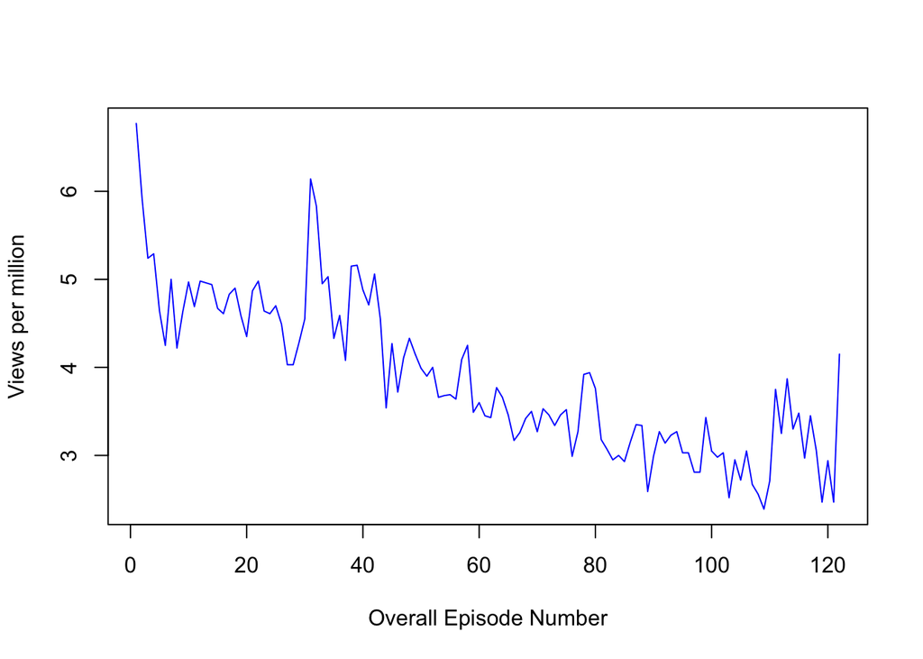

```r
plot(episode_data$No.overall,episode_data$`U.S. viewers(millions)`,type='l', pch = 2, cex = 1.3, col = "blue", xlab= "Overall Episode Number", ylab="Views per million")
```

##### (2) The IMDb rating by episode

I used the plot function to plot the IMDb rating (y) by episode (x).

[figure not shown]

```r
plot(episode_data$No.overall,episode_data$rating,type='l', pch = 2, cex = 1.3, col = "purple", xlab= "Overall Episode Number", ylab="IMDb rating")
```

##### (3) RE score for the 8 characters with the most lines in the show (Y) by episode(x)

First plot the data for the first charcter from the top 8 characters. Then using the par function, add the pther 7 characters to the same plot using a for loop. Then using the legend function, I added the top8 characters to show which color refered to which character.

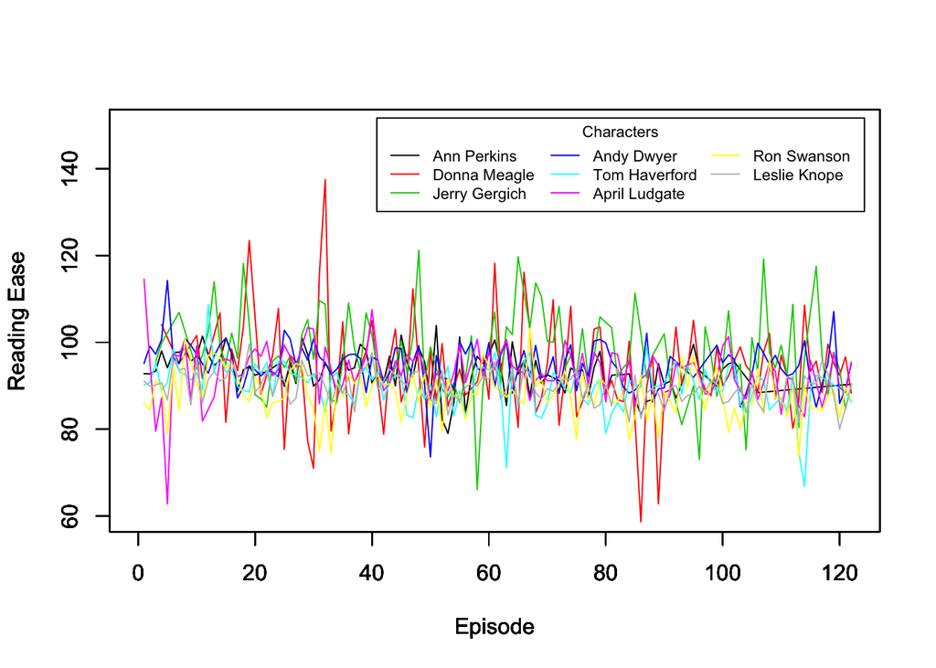

```r
top8 <- names(sort(table(character_data$character))[3:10])

# Plot the first line plot
plot(character_data[which(character_data$character==top8[1]),"No.overall"],character_data[which(character_data$character==top8[1]),"reading_ease"],
     type = 'l', col = 1, xlab = "Episode", ylab = "Reading Ease",
      main = NA, ylim = c(60, 150), xlim = c(0, 122))

# For 2 to 8 in the top8 characters vector
for (i in 2:8){

  # y is the reading ease score per episode of the ith character in top8
  y <- character_data[which(character_data$character==top8[i]),"reading_ease"]

  # x is the number of the episode corresponding to the RE score (in respect to the ith character)
  x <- character_data[which(character_data$character==top8[i]),"No.overall"]

  par(new=TRUE)
  plot(x, y, type = 'l', col = i, xlab = "Episode", ylab = "Reading Ease",
       main = NA, ylim = c(60, 150), xlim = c(0, 122))
}

legend("topright", top8, lty = 1, col = 1:8, ncol = 3, cex = .7, inset = 0.02, title = "Characters")
```

#### (b) Scatter Plots

Using the last example in the ?layout help file, we made a scatter_hist function which inputs two numeric vectors x and y of the same length and produces a scatterplot with marginal hists.

```r
scatter_hist <- function(x, y, x_title = "", y_title = "", p_main = ""){

  xhist <- hist(x, plot = FALSE)
  yhist <- hist(y, plot = FALSE)
  top <- max(c(xhist$counts, yhist$counts))

  nf <- layout(matrix(c(2,0,1,3),2,2,byrow = TRUE), c(3,1), c(1,3), TRUE)
  par(mar = c(3,3,1,1))
  plot(x, y, xlab = x_title, ylab = y_title)
  par(mar = c(0,3,1,1))
  barplot(xhist$counts, axes = FALSE, ylim = c(0, top), space = 0,main=x_title)
  par(mar = c(3,0,1,1))
  barplot(yhist$counts, axes = FALSE, xlim = c(0, top), space = 0, horiz = TRUE,main=y_title)
}
```

Then using the scatter_hist function we made earlier, we created to plots that visualize firstly, ratings against the number of votes by episode and secondly, the viewers in millions against the ratings per episode.

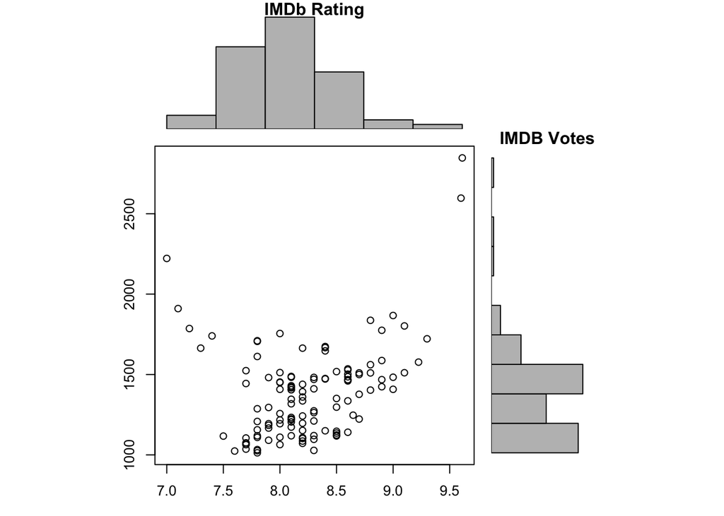

```r
x <- episode_data$rating
y <- episode_data$votes

scatter_hist(x, y, "IMDb Rating","IMDB Votes")
```

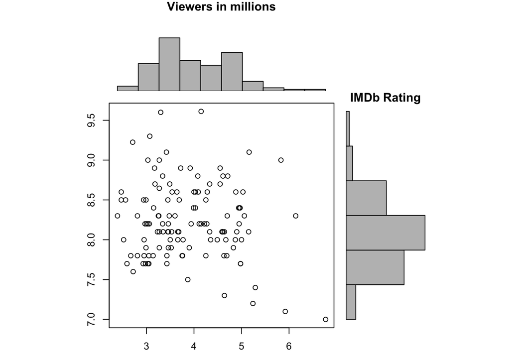

```r
a <- episode_data$`U.S. viewers(millions)`
b <- episode_data$rating

scatter_hist(a, b, "Viewers in millions","IMDb Rating")
```

#### (c) Box Plots

##### (1) IMDb ratins for the writers with 5 or more writing credits

First we found the writers in the data with 5 or more writing credits and set them equal to the objects top writers. Then using a for loop, we found the IMDb ratings for the writers and put it into the writers imdb matrix to use in the plot later. Then we added the names of the writers to the column names of the matrix so it would plot boxplots for each writer and use the name of the writer as an x axis tic mark.  
Then we split the writers into 2 different plot screens so we could visualize them more easily.

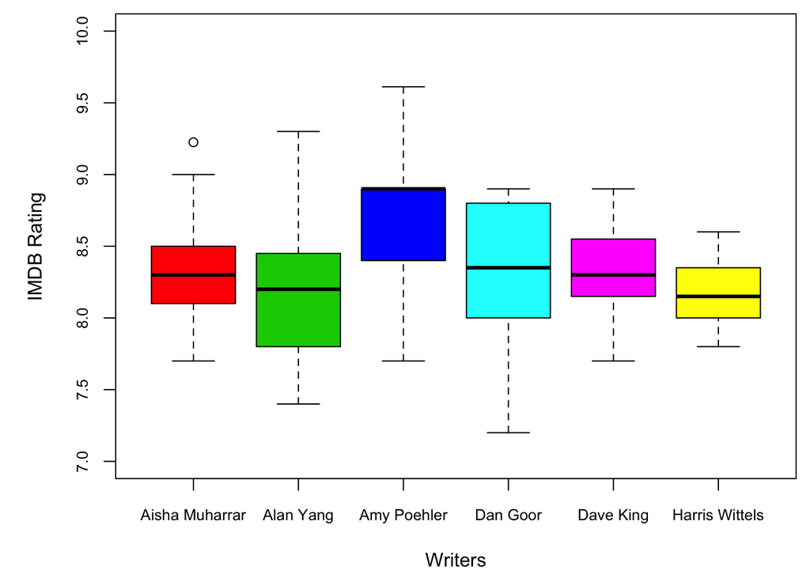

```r
# Find the writers in the episode_data frame with 5 or more writing credits
# Using the strsplit() function to take into account the cowriters

top_writers <- names(which((table(unlist(strsplit(episode_data$`Written by`, split = " & "))) >= 5)))
writers_imdb <- NULL

# for every ith top writer
for (i in 1:length(top_writers)){
  # index vector that finds which indeces of the `Written by` column that contain the ith top writer
  index <- grep(top_writers[i], episode_data$`Written by`)

  # Add column to writers_imdb matrix that contains the ith writer's imdb ratings
  writers_imdb <- cbind(writers_imdb,
                    rep(c(episode_data[index, 'rating'], rep(NA, 17)), length = 17))

}

# Add names
colnames(writers_imdb) <- top_writers

# Plot
par(mar=c(4.3, 5, .6, .6), xpd=TRUE)
boxplot(writers_imdb[,1:6], col = 2:7, ylab = "IMDB Rating", xlab = "Writers", ylim = c(7, 10), cex.axis = .80)
```

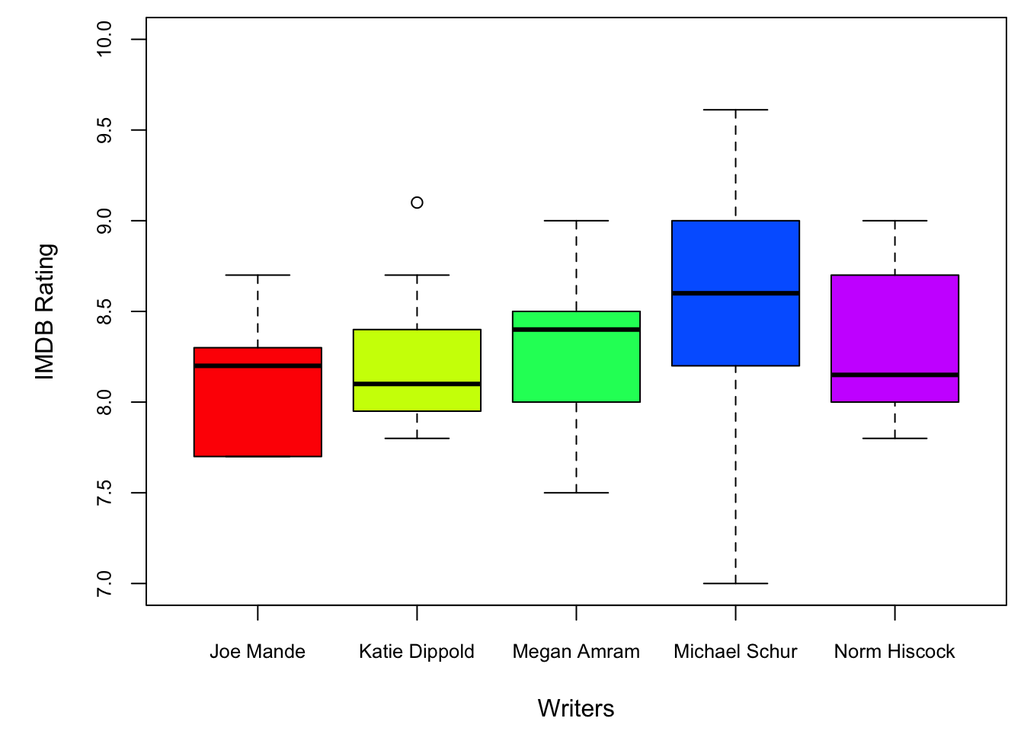

```r
par(mar=c(4.3, 5, .6, .6), xpd=TRUE)
boxplot(writers_imdb[,7:11], col = rainbow(5), ylab = "IMDB Rating", xlab = "Writers", ylim = c(7, 10), cex.axis = .80)
```

##### (2) Viewers for the directors with 5 or more directing credits

Do the same thing we did for the writers but for the top directors and find the views by millions and store it into a matrix. Plot boxplots of this for each of the top directors (looking at views by millions).

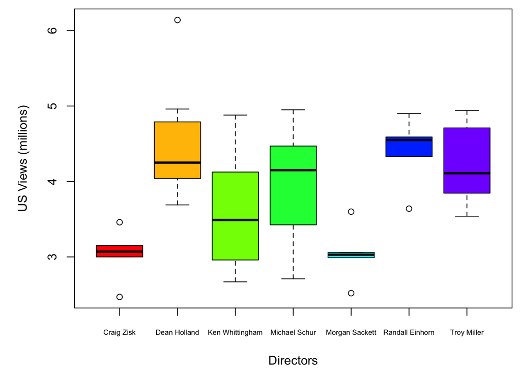

```r
# Find the top directors
top_directors <- names(which(table(episode_data$`Directed by`) >= 5))
director_views <- NULL

# For every ith director
for(i in 1:length(top_directors)){

  # Add column to director_views matrix that contains the ith director's views
  director_views <- cbind(director_views,
                  rep(c(episode_data[which(episode_data$`Directed by`==top_directors[i]),"U.S. viewers(millions)"], rep(NA, 10)), length = 11))
}

# plot
par(mar=c(4.3, 5, .6, .6), xpd=TRUE)
boxplot(director_views, col = rainbow(8), xaxt = 'n', ylab = "US Views (millions)", xlab = "Directors")
axis(side = 1, at = 1:7, labels = top_directors, cex.axis = .58)
```

#### (d) Histograms

##### (1) Andy and April

We plotted overlapping histograms of the episode RE score by character. This compares Andy and April. I used a density histogram instead of frequency hist because it makes it easier to compare the data of the characters. We got the data from the character data data frame. Andy is represented in the blue and April is represented in the purple.

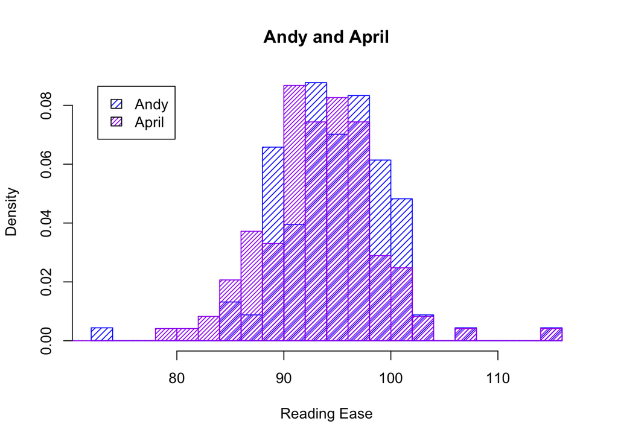

```r
index_andy <- which(character_data$character == "Andy Dwyer")
index_april <- which(character_data$character == "April Ludgate")
hist(character_data[index_andy,"reading_ease"],xlab="Reading Ease",col="blue",main="Andy and April",density=20,breaks=20,prob=TRUE)
hist(character_data[index_april,"reading_ease"],add=TRUE,col="purple",density=30,breaks=20,prob=TRUE)
legend("topleft", c("Andy", "April"), density = c(20, 30),fill = c("blue", "purple"), inset = 0.05)
```

##### (2) Donna and Tom

We plotted overlapping histograms of the episode RE score by character. This compares Donna and Tom. I used a density histogram instead of frequency hist because it makes it easier to compare the data of the characters. We got the data from the character data data frame. Donna is represented in the orange and Tom is represented in the green.

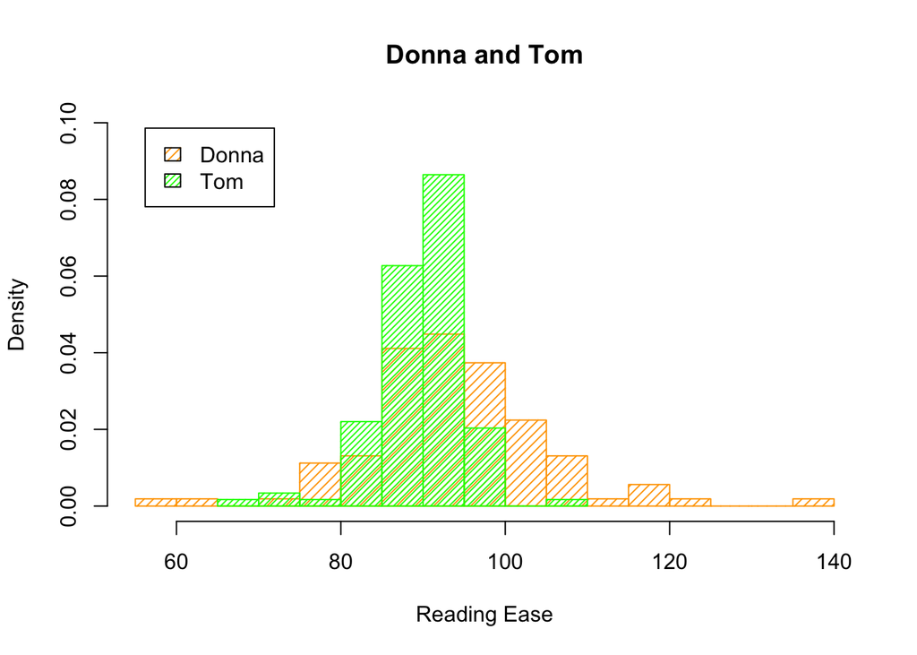

```r
index_donna <- which(character_data$character == "Donna Meagle")
index_tom <- which(character_data$character == "Tom Haverford")
hist(character_data[index_donna,"reading_ease"],xlab="Reading Ease",col="orange",main="Donna and Tom",density=20,breaks=16,prob=TRUE,ylim=c(0.0,0.1))
hist(character_data[index_tom,"reading_ease"],add=TRUE,col="green",density=30,prob=TRUE)
legend("topleft", c("Donna", "Tom"), density = c(20, 30),fill = c("orange", "green"), inset = 0.05)
```

##### (3) Leslie and Ron

We plotted overlapping histograms of the episode RE score by character. This compares Leslie and Ron. I used a density histogram instead of frequency hist because it makes it easier to compare the data of the characters. We got the data from the character data data frame. Leslie is represented in the yellow and Ron is represented in the red

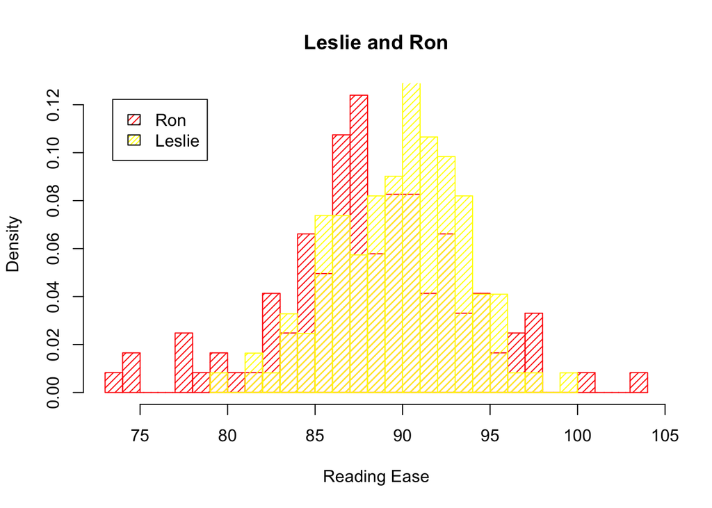

```r
index_leslie <- which(character_data$character == "Leslie Knope")
index_ron <- which(character_data$character == "Ron Swanson")
hist(character_data[index_ron,"reading_ease"],xlab="Reading Ease",col="red",main="Leslie and Ron",density=20,breaks=24,prob=T)
hist(character_data[index_leslie,"reading_ease"],col="yellow",density=20,add=TRUE,breaks=24,prob=T)
legend("topleft", c("Ron", "Leslie"), density = c(20, 30),fill = c("red", "yellow"), inset = 0.05)
```

### Question 6:

#### (1) Flesch RE score for Leslie by line

I found the RE score for Leslie by line and stored it into an object called leslie_RE. I then used the mean and sd function to calculate some of the summary stats for the variable we calculated.

```r
leslie_lines <- scripts[scripts$Character == 'Leslie Knope',]
leslie_RE <- numeric(sum(scripts$Character == 'Leslie Knope'))
for (i in 1:sum(scripts$Character == 'Leslie Knope')){
  leslie_RE[i] <- reading_ease(leslie_lines$Line[i])
}
head(leslie_RE)
```

```
## [1]  36.62000 121.22000  77.81071 103.04429  65.72500 103.04429
```

```r
mean(leslie_RE)
```

```
## [1] 89.97381
```

```r
sd(leslie_RE)
```

```
## [1] 32.36621
```

The mean of the RE scores for leslie by line is 89.97 and the standard deviation if 32.37.

#### (2) Viewers (in millions) per season

I found the views per million by season and stored it into a object called views_season. I then used the mean and sd function to calculate some of the summary stats for the variable we calculated.

```r
views_season <- numeric(7)

for (i in 1:max(episode_data$Season)){
  views_season[i] <- sum(episode_data[episode_data$Season == i, "U.S. viewers(millions)"])
}
views_season
```

```
## [1]  32.11 111.52  75.99  82.20  72.51  58.65  39.16
```

```r
mean(views_season)
```

```
## [1] 67.44857
```

```r
sd(views_season)
```

```
## [1] 27.03375
```

The mean viewers in millions per season is 67.45 and the standard deviation if 27.03.

I found the weighted mean rating per season, weighted by the number of votes. We stored the data into a object called rate_season. I then used the mean and sd function to calculate some of the summary stats for the variable we calculated.

```r
temp_data <- episode_data[episode_data$Season == 1, c("rating", "votes")]
rate_season <- numeric(7)

for (i in 1:max(episode_data$Season)) {
  temp_data <- episode_data[episode_data$Season == i, c("rating", "votes")]
  rate_season[i] <- sum(apply(temp_data, 1, prod)) / sum(temp_data[,2])
}
rate_season
```

```
## [1] 7.281846 8.177257 8.566220 8.368952 8.299409 8.125947 8.674449
```

```r
mean(rate_season)
```

```
## [1] 8.21344
```

```r
sd(rate_season)
```

```
## [1] 0.4555929
```

The weighted mean rating per season, weighted by number of votes is 8.21 and the standard deviation if 0.46.

#### (4) Number of lines per episode

I found the number of lines per episode and stored it in the object line_episode. I then used the mean and sd function to calculate some of the summary stats for the variable we calculated.

```r
line_episode <- numeric(122)

for (i in 1:122){
  line_episode[i] <- sum(scripts$Episode.Num == i)
}

head(line_episode, 3)
```

```
## [1] 475 551 541
```

```r
mean(line_episode)
```

```
## [1] 540.5082
```

```r
sd(line_episode)
```

```
## [1] 81.5284
```

Since there is a lot of data in line_episode, I used the head function to make sure the data is stored properly and it is. The number of lines per episode is 540.51 and the standard deviation if 81.52.

### Question 7: Free Exploration

This looks at the reading ease score for the writers with at least 5 writing credits. We thought this was interesting since we could see the writers who had more complex writing in scripts. We only looked at the writers with 5 or more writing credits so for these writers we had more data to work with. Research questions that come from this is whether the writers with an average higher RE score ended up writing more or less episodes for the show.

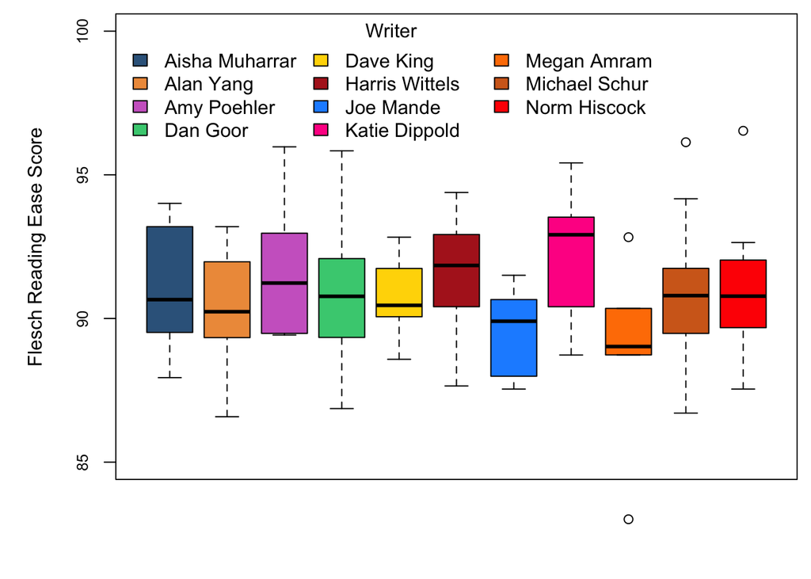

```r
###### Reading Ease Score with each writer with 5 or more writing credits (Box Plot)
newcol <- c("steelblue4", "tan2", "orchid3", "seagreen3", "gold",
            "firebrick", "dodgerblue", "deeppink", "darkorange1", "chocolate","red")

writers_ease <- NULL
for (i in 1:length(top_writers)){
  index <- grep(top_writers[i], episode_data$`Written by`)
  writers_ease <- cbind(writers_ease,
                        rep(c(episode_data[index, 'RE'], rep(NA, 17)), length = 17))

}
colnames(writers_ease) <- top_writers

par(mar=c(4.3, 5, .6, .6), xpd=TRUE)
boxplot(writers_ease, ylab = "Flesch Reading Ease Score", cex.axis = .80,
        ylim = c(85, 100), col = newcol, xaxt = 'n')

legend("topleft", top_writers, fill = c(newcol), title = "Writer", ncol = 3, bty = 'n')
```

This is the second plot we decided to keep. We thought it was interesting (and pretty) because we can easily see how many lines each character has in proportion to the other characters per season. A cool research question that comes from this question is does how much each character makes coresspond to how many lines they have per season. I was thinking about this question since while Ron S is one of the bigger, more important characters, he talks substantially less than some less important characters, Regradless, I doubt he is making less. Its just interesting to think about!

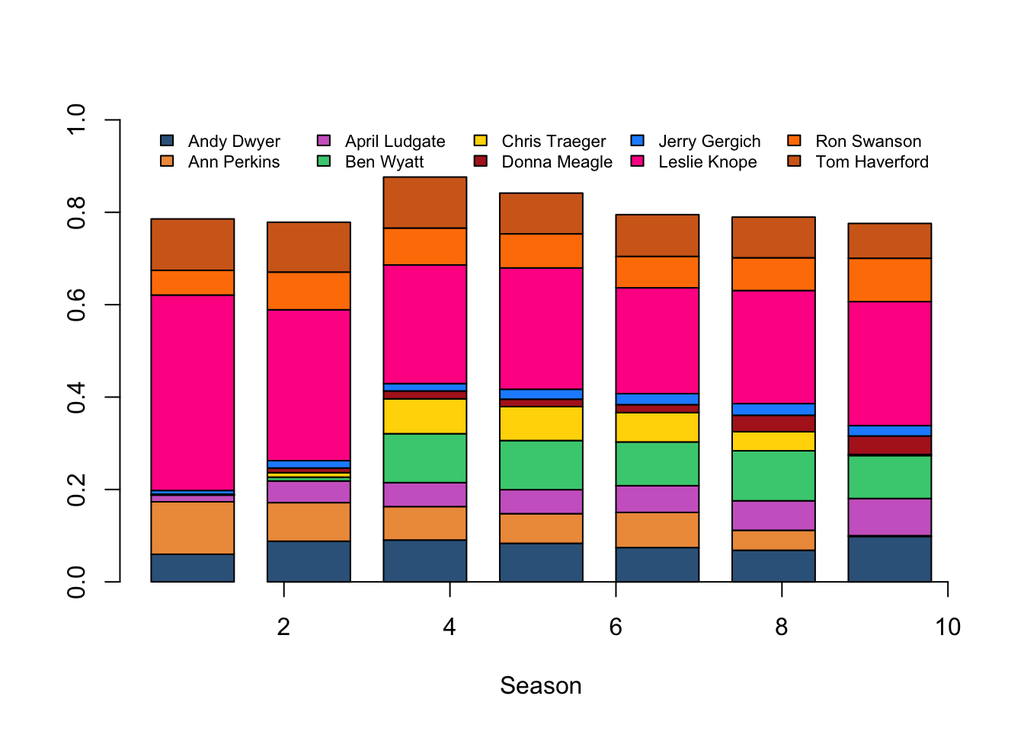

```r
char_prop <- matrix(nrow = 10, ncol = 7)
row.names(char_prop) <- main_characters

for (i in 1:7){
  index <- scripts[scripts$Episode.Num %in% which(episode_data$Season == i),]
  for(j in 1:10){
    char_prop[j,i] <- sum(index$Character == main_characters[j]) / nrow(index)
  }
}

barplot(char_prop, ylim = c(0, 1), col = newcol, space=0.4, xlab="Season")

legend("top", main_characters, fill = newcol, bty = 'n', ncol = 5, cex = .7)

axis(1)
```

These side by side plots show the number of episodes per month in one plot and the viewers per million per month in the other. We thought this was interesting mainly because while december had the least number of episodes it also had the highest average mean of views. Research questions that come from this is does the views per month correspond to the month and are they dependent on each other?

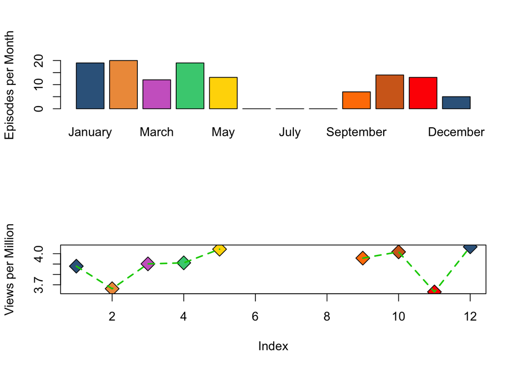

```r
##### views in month compared with episodes per month
month_views <- list()

for(i in 1:12){
  index <- grep(pattern = month.name[i], episode_data$`Original air date`)
  month_views[[i]] <- episode_data$`U.S. viewers(millions)`[index]
}

names(month_views) <- month.name

par(mfrow = c(2, 1))
barplot(unlist(lapply(month_views, length)), col = newcol,ylab="Episodes per Month")
plot(unlist(lapply(month_views, mean)), pch = 23, cex = 2, bg = newcol, xlim = c(1, 12),ylab="Views per Million")
lines(unlist(lapply(month_views, mean)), lty = 2, lwd = 2, col = 3)
```

# Part III: Statistical Inference

### Question 8: Make and Interpret Confidence Intervals

```r
set.seed(904974926)

sample1 <- sample(leslie_RE, size = 100)
t.test(sample1,conf.level = 0.95)
```

```
##
##  One Sample t-test
##
## data:  sample1
## t = 32.167, df = 99, p-value < 2.2e-16
## alternative hypothesis: true mean is not equal to 0
## 95 percent confidence interval:
##  87.00514 98.44456
## sample estimates:
## mean of x
##  92.72485
```

The mean of the sample is 92.72 and the 95% percent interval is bounded by 87.01 and 98.44. The true mean value is captured by the interval. This means we can say with 95% confidence that the mean of the sample is the mean of the data.

Now we are going to repeat these steps 1000 times, and find the proportion of confidence intervals that contain leslie’s true mean re score.

```r
n <- 100
M <- 1000

confidence <- NULL
mean_leslie <- NULL

set.seed(904974926)

for (i in seq_len(M)){
  current_sample <- sample(leslie_RE, size = n)
  t_test <- t.test(current_sample, conf.level = 0.95)

  confidence <- rbind(confidence, t_test$conf.int)
  mean_leslie <- c(mean_leslie, mean(current_sample))
}

true_mean <- mean(leslie_RE) # Mean of the population of students
true_mean
```

```
## [1] 89.97381
```

```r
mean(confidence[,1] <= true_mean & confidence[,2] >= true_mean)
```

```
## [1] 0.941
```

Since we find that leslie’s true mean re score is 89.97, we can then say that the proportion of confidence intervals that contain her true mean re score is 0.941 which makes sense because it is almost 95%.

### Question 9: State and Test a Hypothesis

We are interested in using the mean US views per million per month data to decide if the numerical variable, mean views of a particular month, and the numerical variable, number of episodes per month, are are dependent variables. Basically, we are trying to figure out if there is some sort of corelation between the month certain episodes comes out and the number of viewers in that particular month. To test our hypothesis, since we are comparing two numerical variables, we are going to plot a regression line using the lm and abline functions.

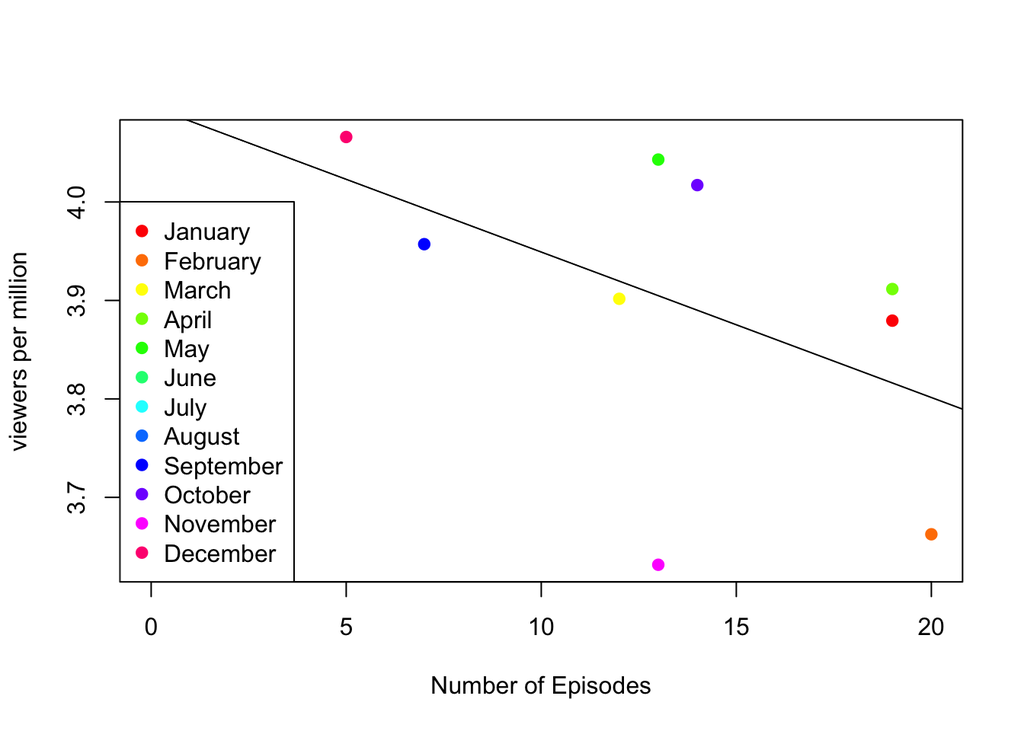

```r
month_views <- list()

for(i in 1:12){
  index <- grep(pattern = month.name[i], episode_data$`Original air date`)
  month_views[[i]] <- episode_data$`U.S. viewers(millions)`[index]
}

names(month_views) <- month.name

#then calculate averages
episode_num <- unlist(lapply(month_views,length)) # number of episodes per month
view_avg <- unlist(lapply(month_views,mean)) # average views per month

plot(episode_num, view_avg, col=rainbow(12), pch = 19, xlab="Number of Episodes",ylab="viewers per million")
legend("bottomleft", month.name, col= rainbow(12), pch = 19)
lin_reg <- lm(view_avg~episode_num)
abline(lin_reg[[1]])
```

### Appendix: Unused Plots

These are the different tries before we got the plots we liked.

This plots the view per million per month where each line plot represents a month. It does show a negative trend where the increase in episodes and decrease of views happen, but we were not happy with the way this looked at all.

```r
plot(month_views[[1]], xlim = c(1, 20), ylim = c(2, 5.5), pch = 19,
     col = 'lightblue', xaxt = 'n', ylab = "US Views (millions)", xlab = NA, type = 'l')

for(i in 2:12){
  par(new = TRUE)
  plot(month_views[[i]], xlim = c(1, 20), ylim = c(2, 5.5), pch = 19, type = 'l',
       col = newcol[i], xaxt = 'n', ylab = NA, xlab = NA)
}
```

[output not shown]

This shows the Flesh Reading score per writer as a scatter plot. We were hoping that certain writers had a very different RE scores than the others, so that would mean some writers wrote more complex writing, but that was not the case. It was all pretty much the same.

```r
##### Reading Ease Score with each writer with 5 or more writing credits (Scatter Plot)
newcol <- c("steelblue4", "tan2", "orchid3", "seagreen3", "gold",
            "firebrick", "dodgerblue", "deeppink", "darkorange1", "chocolate")

plot(episode_data[grep(top_writers[1], episode_data$`Written by`), "RE"],
     ylab = "Flesch Reading Ease Score", xlab = NA, ylim = c(85, 100), xlim = c(1,17), cex = 1, pch = 20, xaxt = 'n')


for(i in 2:11){
  par(new=TRUE)
  plot(episode_data[grep(top_writers[i], episode_data$`Written by`), "RE"], ylab = NA,
       xlab = NA, col = newcol[i], ylim = c(85, 100), xlim = c(1,17), pch = 20, cex = 1, xaxt = 'n')

}

legend("topright", top_writers, fill = c(1, newcol), title = "Writer", ncol = 3, bty = 'n')
```

[output not shown]

This was just looking at the views per million in the month of january. This was the start of looking for a corelation between month and number of views.

```r
hist(month_views[[1]], main = 'Histogram of Views in January', xlab = 'US Viewers (millions)')
```

[output not shown]

This looks at the views per million by month as a boxplot. We did not love the way this was represented since it does not give us a lot of information, so we later changed it to a line plot.

```r
month_views <- list()

for(i in 1:12){
  index <- grep(pattern = month.name[i], episode_data$`Original air date`)
  month_views[[i]] <- episode_data$`U.S. viewers(millions)`[index]
}

names(month_views) <- month.name

boxplot(month_views, main = 'US Views in Months', xlab = "Month", ylab = "US Views (in millions)", col = rainbow(12))
```

[output not shown]

These two barplots are looking that the proportion of lines that ron and leslie had per episode. While this shows that leslie talks a whole lot and ron does not, we realized it would be cooler to see this as a stacked barplot for each character per season. This became our 2nd significant plot in q7.

```r
###### Proportion of Leslie's Lines per episode (Bar Plot)

leslie_prop <- NULL

for (i in 1:length(line_episode)){
  leslie_prop <- c(leslie_prop, sum(scripts$Character == "Leslie Knope" & scripts$Episode.Num == i) / line_episode[i])
}

barplot(leslie_prop, col = episode_data$Season + 1, ylim = c(0, 0.6), xlab = "Propotion of Leslie's Lines Per Episode")
legend("top", legend = 1:7, fill = 2:8, title = 'Season', ncol = 4, inset = .02)

# -------------------------------------------------------------

###### Proportion of Ron's Lines per episode (Bar Plot)

ron_prop <- NULL

for (i in 1:length(line_episode)){
  ron_prop <- c(ron_prop, sum(scripts$Character == "Ron Swanson" & scripts$Episode.Num == i) / line_episode[i])
}

barplot(ron_prop, col = (episode_data$Season + 1), ylim = c(0, 0.4), , xlab = "Proportion of Ron's Lines Per Episode")
legend("topleft", legend = 1:7, fill = 2:8, title = 'Season', ncol = 4, inset = .02)
```

[output not shown]